# Estatística Multivariada

1ª Lista de Exercícios

Elton Dantas de Oliveira Mesquita

## Questão 1

Considerando o seguinte conjunto de observações das variáveis $X_1$ e $X_2$

```r
X1 = c(3,4,2,6,8,2,5)
X2 = c(5,5.5,4,7,10,5,7.5)

X = matrix(c(X1,X2),ncol=2)
```

Calcule estimativas para o vetor de médias, para a matriz de covariâncias e para a matriz de correlação.

```r
# Vetor de médias
mu = apply(X, MARGIN = 2, FUN = mean)
mu
```

```
## [1] 4.285714 6.285714
```

```r
# Matriz de covariâncias
S = cov(X)
S
```

```
##          [,1]     [,2]
## [1,] 4.904762 4.321429
## [2,] 4.321429 4.154762
```

```r
# Matriz de correlação
R = cor(X)
R
```

```
##           [,1]      [,2]
## [1,] 1.0000000 0.9572939
## [2,] 0.9572939 1.0000000
```

## Questão 2

Considerando o seguinte conjunto de observações das variáveis $X_1$, $X_2$ e $X_3$

```r
X1 = c(9,2,6,5,8)
X2 = c(12,8,6,4,10)
X3 = c(3,4,0,2,1)

X = matrix(c(X1,X2,X3),ncol=3)
```

Calcule estimativas para o vetor de médias, para a matriz de covariâncias e para a matriz de correlação.

Vetor de médias

```r
mu = apply(X, MARGIN = 2, FUN = mean)
mu
```

```
## [1] 6 8 2
```

Matriz de covariâncias

```r
S = cov(X)
S
```

```
##       [,1] [,2]  [,3]
## [1,]  7.50  5.0 -1.75
## [2,]  5.00 10.0  1.50
## [3,] -1.75  1.5  2.50
```

Matriz de correlação

```r
R = cor(X)
R
```

```
##            [,1]      [,2]       [,3]
## [1,]  1.0000000 0.5773503 -0.4041452
## [2,]  0.5773503 1.0000000  0.3000000
## [3,] -0.4041452 0.3000000  1.0000000
```

## Questão 3

Considere a matriz

$$A = \begin{bmatrix}
9 & -2 \\
-2 & 6
\end{bmatrix}$$

### a) A matriz $A$ é simétrica?

Seja a matriz

```r
A = matrix(c(9,-2,-2,6),ncol=2)
A
```

```
##      [,1] [,2]
## [1,]    9   -2
## [2,]   -2    6
```

e sua transposta

```r
TA = t(A)
TA
```

```
##      [,1] [,2]
## [1,]    9   -2
## [2,]   -2    6
```

Temos que

```r
A == TA
```

```
##      [,1] [,2]
## [1,] TRUE TRUE
## [2,] TRUE TRUE
```

Como $A = A´$, a matriz $A$ é simétrica.

### b) Mostre que $A$ é positiva definida.

```r
eA = eigen(A)

# Auto valores de A
eA$values > 0
```

```
## [1] TRUE TRUE
```

Como a matriz $A$ é simétrica e seus autovalores são todos positivos, então $A$ é positiva definida.

### c) Determine os autovalores e autovetores da matriz $A$.

Autovalores

```r
eA$values
```

```
## [1] 10  5
```

Autovetores

```r
eA$vectors
```

```
##            [,1]       [,2]
## [1,] -0.8944272 -0.4472136
## [2,]  0.4472136 -0.8944272
```

### d) Encontre $A^{-1}$.

```r
IA = MASS::ginv(A)
IA
```

```
##      [,1] [,2]
## [1,] 0.12 0.04
## [2,] 0.04 0.18
```

### e) Encontre os autovalores e autovetores de $A^{-1}$.

```r
e.IA = eigen(IA)
```

Autovalores

```r
e.IA$values
```

```
## [1] 0.2 0.1
```

Autovetores

```r
e.IA$vectors
```

```
##           [,1]       [,2]
## [1,] 0.4472136 -0.8944272
## [2,] 0.8944272  0.4472136
```

### f) Determine a decomposição espectral de $A$.

Pelo teorema da decomposição espectral, a matriz $A$ pode ser escrita como

$$A = O \Lambda O'$$

```r
O = eA$vectors
Lmbd = diag(eA$values)

O%*%Lmbd%*%t(O)
```

```
##      [,1] [,2]
## [1,]    9   -2
## [2,]   -2    6
```

```r
O%*%Lmbd%*%t(O) == A
```

```
##      [,1] [,2]
## [1,] TRUE TRUE
## [2,] TRUE TRUE
```

## Questão 4

Considere a seguinte matriz de covariâncias associada a uma variável $X$.

$$\Sigma = \begin{bmatrix}
25 & -2 & 4 \\
-2 & 4 & 1 \\
4 & 1 & 9
\end{bmatrix}$$

```r
# Matriz de covariâncias
S = matrix(c(25, -2, 4,
             -2, 4, 1,
             4, 1, 9), nrow = 3)
S
```

```
##      [,1] [,2] [,3]
## [1,]   25   -2    4
## [2,]   -2    4    1
## [3,]    4    1    9
```

### a) Encontre as matrizes $P_x$ e $V^{\frac{1}{2}}$ tais que $V^{\frac{1}{2}}P_xV^{\frac{1}{2}} = \Sigma$.

Matriz $V^{\frac{1}{2}}$

```r
sqrtV = diag(sqrt(diag(S)))
sqrtV
```

```
##      [,1] [,2] [,3]
## [1,]    5    0    0
## [2,]    0    2    0
## [3,]    0    0    3
```

Matriz $P_x$

```r
sqrtV.inv = MASS::ginv(sqrtV)

Px = sqrtV.inv %*% S %*% sqrtV.inv
Px
```

```
##            [,1]       [,2]      [,3]
## [1,]  1.0000000 -0.2000000 0.2666667
## [2,] -0.2000000  1.0000000 0.1666667
## [3,]  0.2666667  0.1666667 1.0000000
```

Verificando a igualdade $V^{\frac{1}{2}}P_xV^{\frac{1}{2}} = \Sigma$

```r
sqrtV %*% Px %*% t(sqrtV) == S
```

```
##      [,1] [,2] [,3]
## [1,] TRUE TRUE TRUE
## [2,] TRUE TRUE TRUE
## [3,] TRUE TRUE TRUE
```

### b) Encontre a média e a variância das seguintes combinações lineares:

#### i. $X_1 - 2X_2$

$E[X_1 - 2X_2] = E[X_1] - 2E[X_2] = \mu_1 - 2\mu_2$

$Var(X_1 - 2X_2) = a^\top \Sigma a$, em que $a^\top = [1,-2,0]$

```r
a = c(1,-2,0)

Var = t(a)%*%S%*%a
Var
```

```
##      [,1]
## [1,]   49
```

#### ii. $X_1 + X_2 + X_3$

$E[X_1 + X_2 + X_3] = E[X_1] + E[X_2] + E[X_3] = \mu_1 + \mu_2 + \mu_3$

$Var(X_1 - 2X_2) = a^\top \Sigma a$, em que $a^\top = [1,1,1]$

```r
a = c(1,1,1)

Var = t(a)%*%S%*%a
Var
```

```
##      [,1]
## [1,]   44
```

#### iii. $3X_1 - 4X_2 + 3X_3$

$E(3X_1 - 4X_2 + 3X_3) = 3E(X_1) - 4E(X_2) + 3E(X_3) = 3\mu_1 - 4\mu_2 + 3\mu_3$

$Var(X_1 - 2X_2) = a^\top \Sigma a$, em que $a^\top = [3,-4,3]$

```r
a = c(3,-4,3)

Var = t(a)%*%S%*%a
Var
```

```
##      [,1]
## [1,]  466
```

## Questão 5

Considere o vetor aleatório $X^\top = (X_1,X_2,X_3,X_4)$ com vetor de médias $\mu^\top = (4,3,2,1)$ e matriz de covariâncias

$$\Sigma = \begin{bmatrix} 3 & 0 & 2 & 2\\
0 & 1 & 1 & 0\\
2 & 1 & 9 & -2\\
2 & 0 & -2 & 4
\end{bmatrix}.$$

```r
mu = c(4,3,2,1)

S = matrix(c(3,0,2,2,
             0,1,1,0,
             2,1,9,-2,
             2,0,-2,4),byrow=T,nrow=4)
```

Particionando $X$ como

$$X = \begin{bmatrix} X_1 \\
X_2 \\
\hline
X_3 \\
X_4
\end{bmatrix}
= \begin{bmatrix} X^{(1)} \\
\hline
X^{(2)}
\end{bmatrix},$$

sendo $A = \begin{bmatrix} 1 & 2 \end{bmatrix}$ e $B = \begin{bmatrix} 1 & -2 \\ 2 & -1 \end{bmatrix}$ , e considerando as combinações lineares $AX^{(1)}$ e $BX^{(2)}$.

```r
A = matrix(c(1,2),byrow=T, nrow=1)

B = matrix(c(1,-2,
             2,-1),byrow = T, nrow=2)
```

Encontre:

### a) $E(X^{(1)})$

```r
mu_X1 = mu[1:2]
mu_X1
```

```
## [1] 4 3
```

### b) $E(AX^{(1)})$

```r
mu_AX1 = A %*% mu_X1
mu_AX1
```

```
##      [,1]
## [1,]   10
```

### c) $Cov(X^{(1)})$

```r
cov_X1 = matrix(c(3,0,
                  0,1), byrow=T, nrow=2)
cov_X1
```

```
##      [,1] [,2]
## [1,]    3    0
## [2,]    0    1
```

### d) $Cov(AX^{(1)})$

```r
cov_AX1 = A %*% cov_X1 %*% t(A)
cov_AX1
```

```
##      [,1]
## [1,]    7
```

### e) $E(X^{(2)})$

```r
mu_X2 = mu[3:4]
mu_X2
```

```
## [1] 2 1
```

### f) $E(BX^{(2)})$

```r
mu_BX2 = B %*% mu_X2
mu_BX2
```

```
##      [,1]
## [1,]    0
## [2,]    3
```

### g) $Cov(X^{(2)})$

```r
cov_X2 = matrix(c(9,-2,
                  -2,4), byrow=T, nrow=2)
cov_X2
```

```
##      [,1] [,2]
## [1,]    9   -2
## [2,]   -2    4
```

### h) $Cov(BX^{(2)})$

```r
cov_BX2 = B %*% cov_X2 %*% t(B)
cov_BX2
```

```
##      [,1] [,2]
## [1,]   33   36
## [2,]   36   48
```

### i) $Cov(X^{(1)},X^{(2)})$

```r
cov_X1_X2 = matrix(c(2,2,
                    1,0), byrow=T, nrow=2)
cov_X1_X2
```

```
##      [,1] [,2]
## [1,]    2    2
## [2,]    1    0
```

### j) $Cov(AX^{(1)},BX^{(2)})$

```r
cov_AX1_AX2 = (A) %*% cov_X1_X2 %*% t(B)
cov_AX1_AX2
```

```
##      [,1] [,2]
## [1,]    0    6
```

## Questão 6

Considere a distribuição normal bivariada com parâmetros $\mu_1 = 0$, $\mu_2 = 2$, $\sigma_{11} = 2$, $\sigma_{22} = 1$ e $\rho_{12} = 0.5$.

Vetor de médias $\mu$

```r
mu = c(0,2)
```

Matriz de covariâncias $\Sigma$

```r
S = matrix(c(2, sqrt(2)/2,
             sqrt(2)/2,1), byrow=T, nrow=2)
S
```

```
##           [,1]      [,2]
## [1,] 2.0000000 0.7071068
## [2,] 0.7071068 1.0000000
```

### a) Escreva a densidade dessa normal bivariada.

Seja

$$X = \begin{pmatrix}
x_1 \\
x_2
\end{pmatrix}
\sim
N_2\left(\mu = \begin{bmatrix}
0 \\
2
\end{bmatrix},
\Sigma = \begin{bmatrix}
2 & \frac{\sqrt{2}}{2} \\
\frac{\sqrt{2}}{2} & 1
\end{bmatrix}\right)$$

A função densidade de $X$ é dada por

$$\begin{aligned}
f(x_1,x_2) &= f(X) = \frac{1}{2\pi|\Sigma|^{1/2}} \times \exp\left\{-\frac{1}{2}(X-\mu)^\top\Sigma^{-1}(X-\mu)\right\} \\
&=
\frac{1}{2\pi\sqrt{\sigma_{11}\sigma_{22}(1-\rho_{12}^2)}} \times \exp\left\{-\frac{1}{2(1-\rho_{12}^2)}\left[\left(\frac{x_1-\mu_1}{\sqrt{\sigma_{11}}}\right)^2+\left(\frac{x_2-\mu_2}{\sqrt{\sigma_{22}}}\right)^2-2\rho_{12}\frac{(x_1-\mu_1)(x_2-\mu_2)}{\sqrt{\sigma_{11}\sigma_{22}}}\right]\right\} \\
&=
\frac{1}{2\pi\sqrt{\frac{3}{2}}} \times \exp\left\{-\frac{2}{3}\left[\frac{x_1^2}{2}+(x_2-2)^2-\frac{x_1(x_2-2)}{\sqrt{2}}\right]\right\}
\end{aligned}$$

### b) Escreva a expressão do quadrado da distância de Mahalanobis.

A quantidade $(x-\mu)'\Sigma^{-1}(x-\mu)$ é referida como a distância de Mahalanobis (1936) do vetor $x$ ao vetor de médias $\mu$. Ela também é denominada de distância padronizada ou distância estatística.

### c) Determine a equação do contorno de probabilidade para $\alpha = 50\%$.

Quantil da $\chi_{(2;50\%)}^2$

```r
round(qchisq(p = 0.5, df = 2),2)
```

```
## [1] 1.39
```

Equação do contorno de probabilidade para $\alpha = 50\%$

[figure not shown]

```r
plot(ellipse::ellipse(S,centre=c(2,0),level=0.5,npoints=100),
     type="l",asp=0, lwd=2, col="darkblue")
points(c(2,0),pch=16)
segments(x0=0, x1=2, y0=0, lty=2)
segments(y0=-1.5, y1=0, x0=2, lty=2)
```

## Questão 7

Vetor de médias $\mu$

```r
mu = c(2,-3,1)
mu
```

```
## [1]  2 -3  1
```

Matriz de covariâncias $\Sigma$

```r
S = matrix(c(1,1,1,
             1,3,2,
             1,2,2), byrow=T, nrow=3)
S
```

```
##      [,1] [,2] [,3]
## [1,]    1    1    1
## [2,]    1    3    2
## [3,]    1    2    2
```

### a) Encontre a distribuição de $3X_1 - 2X_2 + 3X_3$

Seja $Y = 3X_1 - 2X_2 + 3X_3$ e $a^\top = [3,-2,3]$

Vetor de constantes

```r
a = c(3,-2,3)
```

Vetor de médias de Y

```r
muY = t(a) %*% mu
muY
```

```
##      [,1]
## [1,]   15
```

Matriz de covariâncias de Y

```r
SY = t(a) %*% S %*% a
SY
```

```
##      [,1]
## [1,]   21
```

Então $Y = 3X_1 - 2X_2 + 3X_3 = [3,-2,3]X$ e, assim, $Y \sim N(15,21)$.

### b) Encontre a distribuição do vetor $Z^\top = [X_1,X_2]$

Seja $Z = \begin{pmatrix}X_1 \\ X_2 \end{pmatrix}$ um subconjunto de $X$,

Vetor de médias de Z

```r
muZ = mu[1:2]
muZ
```

```
## [1]  2 -3
```

Matriz de covariâncias de Z

```r
SZ = matrix(c(1,1,
              1,3),byrow=T,nrow=2)
SZ
```

```
##      [,1] [,2]
## [1,]    1    1
## [2,]    1    3
```

Então, $Z \sim N_2\left(\mu^\top=[2,-3],\Sigma=\begin{bmatrix} 1 & 1 \\ 1 & 3\end{bmatrix}\right).$

### c) Calcule a $Cov(Z,X3)$

Seja

$$Y = \begin{bmatrix} Z \\ \hline X_3 \end{bmatrix} = \begin{bmatrix} X_1 \\ X_2 \\ \hline X_3 \end{bmatrix}.$$

Temos que

$$Cov(Y) = \left[\begin{array}{cc|c} 1 & 1 & 1 \\ 1 & 3 & 2 \\ \hline 1 & 2 & 2 \end{array}\right].$$

Então,

$$Cov(Z,X_3) = Cov((X_1,X_2),X_3) = \begin{bmatrix} 1 \\ 2\end{bmatrix}.$$

## Questão 8

Seja $X_1 \sim N(0,1)$. Temos que,

$$\begin{aligned}
F_{X_1}(x_1) &= P(X_1 \leq x_1) \\
&= P(X_1 < -1) + P(-1 < X_1 < x_1)
\end{aligned}$$

e por simetria,

$$P(-1 < X_1 < x_1) = P(-x_1 < X_1 < 1)$$
.

Quando $-1 < x_2 < 1$,

$$\begin{aligned}
F_{X_2}(x_2) &= P(X_2 \leq x_2) \\
&= P(X_2 < -1) + P(-1 < X_2 < x_2) \\
&= P(X_1 < -1) + P(-1 < -X_1 < x_2) \\
&= P(X_1 < -1) + P(-x_2 < X_1 < 1)
\end{aligned}$$

Mas, por simetria,

$$P(-x_2 < X_1 < 1) = P(-1 < X_1 < x_2)$$
Assim,

$$\begin{aligned}
F_{X_2}(x_2) &= P(X_2 \leq x_2) \\
&= P(X_1 < -1) + P(-1 < X_1 < x_2) \\
&= P(X_1 < x_2) \\
&= F_{X_1}(x_2)
\end{aligned}$$

que é uma função distribuição de uma normal padrão. Ou seja, $X_2$ também tem densidade normal padrão.

## Questão 9

Os dados abaixo mostram a idade ($X_1$ em anos) e o preço de venda ($X_2$ em unidades de $US\$ 1000$) para $n = 10$ carros usados.

```r
x1 = c(3,5,5,7,7,7,8,9,10,11)
x2 = c(2.3,1.9,1,0.7,0.3,1,1.05,0.45,0.7,0.3)
X = matrix(c(x1,x2),ncol=2)
X
```

```
##       [,1] [,2]
##  [1,]    3 2.30
##  [2,]    5 1.90
##  [3,]    5 1.00
##  [4,]    7 0.70
##  [5,]    7 0.30
##  [6,]    7 1.00
##  [7,]    8 1.05
##  [8,]    9 0.45
##  [9,]   10 0.70
## [10,]   11 0.30
```

Desenhe o contorno de probabilidade de $90\%$ e conte quantas observações estão no interior do contorno.

Vetor de médias $\mu$ e matriz de covariâncias $\Sigma$

```r
# Vetor de médias
mu = apply(X,2,mean)
mu
```

```
## [1] 7.20 0.97
```

```r
# Matriz de covariâncias
S = cov(X)
S
```

```
##           [,1]       [,2]
## [1,]  5.955556 -1.2988889
## [2,] -1.298889  0.4395556
```

Desenho do contorno de probabilidade de $90\%$

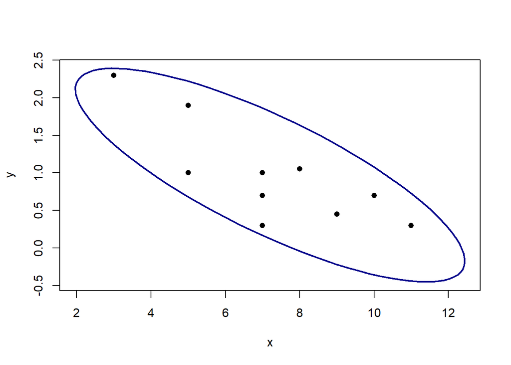

```r
plot(ellipse::ellipse(S,centre=mu,level=0.9,npoints=100),
     type="l",asp=0, lwd=2, col="darkblue")
points(X,pch=16)
```

Todas as 10 observações estão dentro do contorno de probabilidade.

## Questão 10

Sejam $X \sim N_3(\mu,\Sigma)$, com $\mu^\top = [-3,1,4]$ e $\Sigma = \begin{bmatrix} 1 & -2 & 0 \\ -2 & 5 & 0 \\ 0 & 0 & 2 \end{bmatrix}$.

Qual(is) das seguintes variáveis são independentes? Justifique.

Para essa questão, utilizaremos a propriedade da distribuição normal multivariada de que covariância zero implica que as suas componentes são independentemente distribuídas.

### a) $X_1$ e $X_2$

Seja $Y = \begin{bmatrix} X_1 \\ X_2 \end{bmatrix}$. Temos que $Cov(Y) = \begin{bmatrix} 1 & -2 \\ -2 & 5 \end{bmatrix}$.

Assim, $Cov(X_1,X_2) = \sigma_{12} = -2\neq 0$.

Portanto, $X_1$ e $X_2$ não são independentes.

### b) $X_2$ e $X_3$

Seja $Y = \begin{bmatrix} X_2 \\ X_3 \end{bmatrix}$. Temos que $Cov(Y) = \begin{bmatrix} 5 & 0 \\ 0 & 2 \end{bmatrix}$.

Assim, $Cov(X_1,X_2) = \sigma_{23} = 0$.

Portanto, $X_2$ e $X_3$ são independentes.

### c) $(X_1,X_2)$ e $X_3$

Seja $Y = \begin{bmatrix} X_1 \\ X_2 \\ \hline X_3 \end{bmatrix}$. Temos que $Cov(Y) = \left[\begin{array}{cc|c} 1 & -2 & 0 \\ -2 & 5 & 0 \\ \hline 0 & 0 & 2 \end{array}\right]$.

Assim, $Cov((X_1,X_2),X_3) = \begin{bmatrix}0 \\ 0\end{bmatrix}$. Ou seja, $\sigma_{13} = \sigma_{23} = 0$.

Portanto, $(X_1,X_2)$ e $X_3$ são independentes.

### d) $\frac{X_1+X_2}{2}$ e $X_3$

Seja

$$\begin{bmatrix} \frac{X_1+X_2}{2} \\ X_3 \end{bmatrix}
=
\begin{bmatrix} \frac{1}{2} & \frac{1}{2} & 0 \\ 0 & 0 & 1 \end{bmatrix}
\begin{bmatrix} X_1 \\ X_2 \\ X_3 \end{bmatrix}
= AX$$

Então

$$Cov(\frac{X_1+X_2}{2},X_3) = Cov(AX) = A \Sigma A^\top$$

Encontrando a matriz de covariâncias $A \Sigma A^\top$

```r
A = matrix(c(0.5,0.5,0,
             0,0,1), byrow=T, nrow=2)

S = matrix(c(1,-2,0,
             -2,5,0,
             0,0,2),byrow=T,nrow=3)

AStA = A %*% S %*% t(A)
AStA
```

```
##      [,1] [,2]
## [1,]  0.5    0
## [2,]  0.0    2
```

Como na matriz $A \Sigma A^\top$ encontrada acima $\sigma_{12} = \sigma_{21} = 0$, as variáveis $\frac{X_1+X_2}{2}$ e $X_3$ são independentes.